# Weekly 8: A Report for Coach Getsee

Author

Chris Murphy

## Overview

Coach Getsee asked us what his pitchers’ stuff looks like, specifically their **movement profiles** and their **release profiles**. In class we built a movement profile for Nathan Hale. This week you’ll build a short report for one other pitcher.

The report has two figures:

1. his **movement profile** (what we did in class)
2. his **release geometry**: where the ball leaves his hand

and a short note telling coach what to look at.

A few things:

1. Add `#| echo: false` to your code blocks. Coach should see charts and words, not code.
2. Use a new block when you move to a new task.
3. Code goes in the blocks. **Answers go outside them**, as prose.
4. Every chart uses a colorblind-safe palette, and each pitch type is **the same color in both figures**.

Due Thursday, November 19 at 8pm.

# Part 1: Get to know your pitcher

This part is for you. It won’t go in the report, but you can’t build the report without it.

We’re using the same colors for every pitcher, so that a slider is the same color in every report coach gets. Run this as is. If your pitcher throws a pitch type that isn’t here, add it.

> Filter to your pitcher. How many pitches does he have, and over how many days? Which hand does he throw with?

```
# A tibble: 1 × 3
  pitches  days throwing_hand
    <int> <int> <chr>
1     246     6 Left
```

> Compare `TaggedPitchType` and `AutoPitchType` for your pitcher. Which column will you use, and why? I will use taggedpitchtype, the trackman is not great at discerning pitch types from d3 pitchers and I doubt a d3 pitcher is throwing so many different types of pitches.

```
# A tibble: 12 × 3
   TaggedPitchType AutoPitchType     n
   <chr>           <chr>         <int>
 1 ChangeUp        Changeup         53
 2 ChangeUp        Curveball         5
 3 ChangeUp        Slider            7
 4 Cutter          Slider            3
 5 Fastball        Changeup         71
 6 Fastball        Four-Seam         1
 7 Fastball        Sinker           15
 8 Sinker          Changeup         13
 9 Sinker          Sinker            2
10 Slider          Changeup          1
11 Slider          Curveball        39
12 Slider          Slider           36
```

> Which pitch types does he throw often enough to say something about? What will you do with the rest? Changup, fastball, sinker, and slider. I will leave out cutter because 3 is not enough pitches to go off of.

**If your pitcher throws left-handed:** horizontal break is backwards for him compared to Hale To fix it, flip the sign of HorzBreak when you filter to your pitcher so that positive means “arm side” for every pitcher. To do this you would include `mutate(HorzBreak = -HorzBreak`. This is only necessary if your pitcher is left handed.

# Part 2: The report

Everything in this part goes to coach.

## His movement profile

> Make a movement profile for your pitcher that coach can read without you in the room. Use what we did in class: labels instead of a legend, how many pitches are behind each label, the raw pitches in the background, and a title that tells coach what to see.

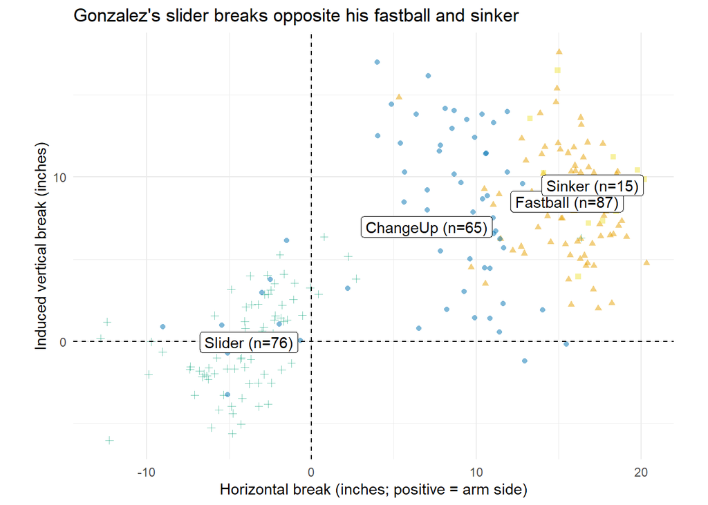

## His release geometry

`RelSide` and `RelHeight` are where the ball leaves his hand, in feet: side to side, and how high. (Check the glossary for where 0 is.) Coaches care about this because if one pitch comes out of a different spot than the others, a hitter can pick it up early.

> Make a figure that answers: **does every pitch come out of the same place?** The design is up to you. A few things to think about:
> - Both axes are in feet. What did Wilke say about that?
> - The differences here might be small. Is a foot the right unit for coach?
> - Does coach need every pitch, the average for each pitch type, or both?
> - Each pitch type has to be the same color it was in your movement profile.

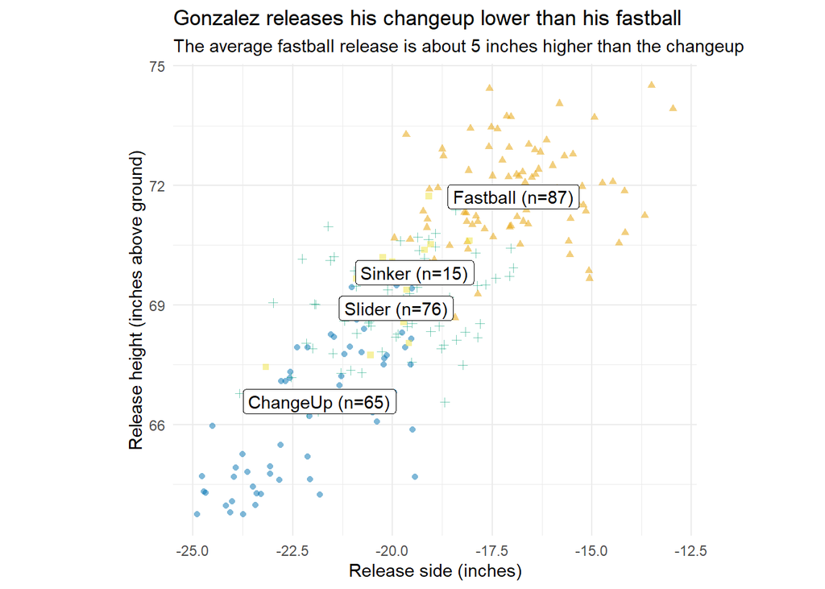

## A note for coach

# Part 3: Behind the report

This part is for me, not coach.

> Was there anything in the data you weren’t sure about for your pitcher? What did you do about it?

> The automatic pitch classifications did not always match the tagged classifications, so I compared the two columns, used TaggedPitchType for both figures, and excluded the cutter because it had only three pitches. I also reversed the horizontal break for this left-handed pitcher so that positive values mean arm-side movement.

# Disclosure appendix

> What did you try first? Include the code you wrote and the actual error message, or a clear description of the problem if there was no error.

> If you used an AI system: the exact prompt, exactly what it returned, what it got wrong or left unclear, and what you changed.

> If you didn’t use one, say so.

> I asked chatgpt the following.

> Help me create a title for the graph that explains what is being shown. (I added the file of my assignment and the csv so it could know what my graph was about and what it contained.)

> Sure thing. title = “Gonzalez’s slider breaks opposite his fastball and sinker”

> Do the same thing for the second graph.

> Here is a title for the second graph that meets the conditions you previously provided. title = “Gonzalez releases his changeup lower than his fastball”

# Before you submit

Render in a clean session: restart R, then render. Read your report as if you were coach: does every chart make sense without anything from class? Commit and push the `.qmd` and the `.html`.